# Making Music From Images

This project will showcase how an image can be turned into sound in Python. The program will take a picture as input and produce a numpy array composed of frequencies that can be played.

The basic idea is as follows:

- Images are made of pixels.
- Pixels are composed of arrays of numbers that designate color
- Color is described via color spaces like RGB or HSV for example
- The color could be potentially mapped into a wavelength
- Wavelength can be readily converted into a frequency
- Sound is vibration that can be chracterized by frequencies
- Therefore, an image could be translated into sound

With that in mind, let's get started!

## Modules Used in this work

Here are the most important modules used for this project:

- open cv : Used to carry out operations on images
- numpy : Used to perform computations on array data
- pandas : Used to load, process, analyze, operate and export dataframes
- matplotlib.pyplot :Used for plotting/visualizing our results
- librosa : Used for musical/audio operations

The API documentation for each of these modules can be found here:

- [https://pandas.pydata.org](https://pandas.pydata.org/docs/reference/index.html)
- https://matplotlib.org/stable/api/index.html
- https://numpy.org/doc/stable/reference/index.html#reference
- https://docs.opencv.org/3.4/index.html
- https://librosa.org/doc/latest/index.html

```python
#Importing modules
import cv2
import matplotlib.pyplot as plt
from matplotlib import cm
import numpy as np
import pandas as pd
import IPython.display as ipd
import librosa
from midiutil import MIDIFile
import random
```

## Loading Image

I'll start by loading the image using the `imread` function in OpenCV. The `imread` function loads images in BGR format by default so I'll change this to RGB to ensure that the colors are parsed/displayed correctly. The image on the left is how `imread` loads the image (BGR format) and the image on the right is after converting the color space to RGB (this is how the picture looked from the source file.

[figure not shown]

```
           Image Properties
Height =  360 Width =  640
Number of pixels in image =  230400
```

```python
#Load the image
ori_img = cv2.imread('colors.jpg')
img = cv2.cvtColor(ori_img, cv2.COLOR_BGR2RGB)

#Get shape of image
height, width, depth = img.shape
dpi = plt.rcParams['figure.dpi']
figsize = width / float(dpi), height / float(dpi)

#Plot the image
fig, axs = plt.subplots(1, 2, figsize = figsize)
axs[0].title.set_text('BGR')
axs[0].imshow(ori_img)
axs[1].title.set_text('RGB')
axs[1].imshow(img)
plt.show()
print('           Image Properties')
print('Height = ',height, 'Width = ', width)
print('Number of pixels in image = ', height * width)
```

## Using HSV Color Space

HSV is color space that is controlled by 3 values. The 3 values are Hue, Saturation, and Brightness.

[figure not shown]

Hue is defined as "the degree to which a stimulus can be described as similar to or different from stimuli that are described as red, orange, yellow, green, blue, violet". In other words, Hue represents color.

Saturation is defined as "colorfulness of an area judged in proportion to its brightness". In other words, Saturation represents the amount to which a color is mixed with white.

Hue values of basic colors:

- Orange 0-44
- Yellow 44- 76
- Green 76-150
- Blue 150-260
- Violet 260-320
- Red 320-360

I'll work in HSV color space because I figured it be a little easier to work

[figure not shown]

```python
#Need function that reads pixel hue value
hsv = cv2.cvtColor(ori_img, cv2.COLOR_BGR2HSV)
#Plot the image
fig, axs = plt.subplots(1, 3, figsize = (15,15))
names = ['BGR','RGB','HSV']
imgs  = [ori_img, img, hsv]
i = 0
for elem in imgs:
    axs[i].title.set_text(names[i])
    axs[i].imshow(elem)
    axs[i].grid(False)
    i += 1
plt.show()
```

## Extract Hue from Image

Now that we have our image in HSV, let's extract the hue (H) value from every pixel. This can be done via a nested for loop over the height and width of the image.

```python
i=0 ; j=0
#Initialize array the will contain Hues for every pixel in image
hues = []
for i in range(height):
    for j in range(width):
        hue = hsv[i][j][0] #This is the hue value at pixel coordinate (i,j)
        hues.append(hue)
```

Now that we have an array containing the H value for every pixel, I'll place that result into a pandas dataframe. Each row in the dataframe is a pixel and thus each column will contain information about that pixel. I'll call this dataframe `pixels_df`

```python
pixels_df = pd.DataFrame(hues, columns=['hues'])
pixels_df
```

|  | hues |
| --- | --- |
| 0 | 8 |
| 1 | 31 |
| 2 | 21 |
| 3 | 26 |
| 4 | 33 |
| ... | ... |
| 230395 | 20 |
| 230396 | 20 |
| 230397 | 17 |
| 230398 | 17 |
| 230399 | 22 |

230400 rows × 1 columns

## Converting hues to frequencies (1st Idea)

My initial idea at converting a hue value into a frequency involved a simple mapping between a predetermined set of frequencies to the H value. The mapping function is shown below. The function takes the H value and an array containing frequencies to map H to as inputs. Below, the example uses an array called `scale_freqs` to define the frequencies. The frequencies used in `scale_freqs` correspond to the A Harmonic Minor Scale. Then, an array of threshold values (called `thresholds`) for H is defined. This array of thresholds can then be used to convert H into a frequency from `scale_freqs`.

```python
#Define frequencies that make up A-Harmonic Minor Scale
scale_freqs = [220.00, 246.94 ,261.63, 293.66, 329.63, 349.23, 415.30]
def hue2freq(h,scale_freqs):
    thresholds = [26 , 52 , 78 , 104,  128 , 154 , 180]
    note = scale_freqs[0]
    if (h <= thresholds[0]):
         note = scale_freqs[0]
    elif (h > thresholds[0]) & (h <= thresholds[1]):
        note = scale_freqs[1]
    elif (h > thresholds[1]) & (h <= thresholds[2]):
        note = scale_freqs[2]
    elif (h > thresholds[2]) & (h <= thresholds[3]):
        note = scale_freqs[3]
    elif (h > thresholds[3]) & (h <= thresholds[4]):
        note = scale_freqs[4]
    elif (h > thresholds[4]) & (h <= thresholds[5]):
        note = scale_freqs[5]
    elif (h > thresholds[5]) & (h <= thresholds[6]):
        note = scale_freqs[6]
    else:
        note = scale_freqs[0]

    return note
```

I can then apply this mapping using a lambda function to every row in the hues column to get the frequencies associated with each H value. The results of this process will be saved into a column called `notes`

```python
pixels_df['notes'] = pixels_df.apply(lambda row : hue2freq(row['hues'],scale_freqs), axis = 1)
pixels_df
```

|  | hues | notes |
| --- | --- | --- |
| 0 | 8 | 220.00 |
| 1 | 31 | 246.94 |
| 2 | 21 | 220.00 |
| 3 | 26 | 220.00 |
| 4 | 33 | 246.94 |
| ... | ... | ... |
| 230395 | 20 | 220.00 |
| 230396 | 20 | 220.00 |
| 230397 | 17 | 220.00 |
| 230398 | 17 | 220.00 |
| 230399 | 22 | 220.00 |

230400 rows × 2 columns

Cool! Now, I'll convert the `notes` column into a numpy array called `frequencies` since I can then use this to make a playable audio file :]

```python
frequencies = pixels_df['notes'].to_numpy()
```

```python
song = np.array([])
sr = 22050 # sample rate
T = 0.1    # 0.1 second duration
t = np.linspace(0, T, int(T*sr), endpoint=False) # time variable
#Make a song with numpy array :]
#nPixels = int(len(frequencies))#All pixels in image
nPixels = 60
for i in range(nPixels):
    val = frequencies[i]
    note  = 0.5*np.sin(2*np.pi*val*t)
    song  = np.concatenate([song, note])
ipd.Audio(song, rate=sr) # load a NumPy array
```

[interactive chart not shown]

That's pretty neat! Let me play with it a bit more. I decided to include the effect of octaves (i.e., make notes sound higher or lower) into my 'song-making' routine. The octave to be used for a given note will be chosen at random from an array.

```python
song = np.array([])
octaves = np.array([0.5,1,2])
sr = 22050 # sample rate
T = 0.1    # 0.1 second duration
t = np.linspace(0, T, int(T*sr), endpoint=False) # time variable
#Make a song with numpy array :]
#nPixels = int(len(frequencies))#All pixels in image
nPixels = 60
for i in range(nPixels):
    octave = random.choice(octaves)
    val =  octave * frequencies[i]
    note  = 0.5*np.sin(2*np.pi*val*t)
    song  = np.concatenate([song, note])
ipd.Audio(song, rate=sr) # load a NumPy array
```

[interactive chart not shown]

Awesome! We do have all these pixels, how about we try using them by picking the frequencies from random pixels?

```python
song = np.array([])
octaves = np.array([1/2,1,2])
sr = 22050 # sample rate
T = 0.1    # 0.1 second duration
t = np.linspace(0, T, int(T*sr), endpoint=False) # time variable
#Make a song with numpy array :]
#nPixels = int(len(frequencies))#All pixels in image
nPixels = 60
for i in range(nPixels):
    octave = random.choice(octaves)
    val =  octave * random.choice(frequencies)
    note  = 0.5*np.sin(2*np.pi*val*t)
    song  = np.concatenate([song, note])
ipd.Audio(song, rate=sr) # load a NumPy array
```

[interactive chart not shown]

I know it's a bit of a meme, but "Is this math rock?"

[figure not shown]

Let me compile everything so far into a single function

```python
def img2music(img, scale = [220.00, 246.94 ,261.63, 293.66, 329.63, 349.23, 415.30],
              sr = 22050, T = 0.1, nPixels = 60, useOctaves = True):
    """
    Args:
        img    :     (array) image to process
        scale  :     (array) array containing frequencies to map H values to
        sr     :     (int) sample rate to use for resulting song
        T      :     (int) time in seconds for dutation of each note in song
        nPixels:     (int) how many pixels to use to make song
    Returns:
        song   :     (array) Numpy array of frequencies. Can be played by ipd.Audio(song, rate = sr)
    """
    #Convert image to HSV
    hsv = cv2.cvtColor(ori_img, cv2.COLOR_BGR2HSV)

    #Get shape of image
    height, width, depth = ori_img.shape

    i=0 ; j=0 ; k=0
    #Initialize array the will contain Hues for every pixel in image
    hues = []
    for i in range(height):
        for j in range(width):
            hue = hsv[i][j][0] #This is the hue value at pixel coordinate (i,j)
            hues.append(hue)

    #Make dataframe containing hues and frequencies
    pixels_df = pd.DataFrame(hues, columns=['hues'])
    pixels_df['frequencies'] = pixels_df.apply(lambda row : hue2freq(row['hues'],scale), axis = 1)
    frequencies = pixels_df['frequencies'].to_numpy()

    song = np.array([])
    octaves = np.array([0.5,1,2])
    t = np.linspace(0, T, int(T*sr), endpoint=False) # time variable
    #Make a song with numpy array :]
    #nPixels = int(len(frequencies))#All pixels in image
    for k in range(nPixels):
        if useOctaves:
            octave = random.choice(octaves)
        else:
            octave = 1
        val =  octave * frequencies[k]
        note  = 0.5*np.sin(2*np.pi*val*t)
        song  = np.concatenate([song, note])

    return song
```

One more thing that would be nice to have is a procedural way to generate musical scales. Katie He has a lovely set of routines made that I copied below from this article https://towardsdatascience.com/music-in-python-2f054deb41f4

```python
def get_piano_notes():
    # White keys are in Uppercase and black keys (sharps) are in lowercase
    octave = ['C', 'c', 'D', 'd', 'E', 'F', 'f', 'G', 'g', 'A', 'a', 'B']
    base_freq = 440 #Frequency of Note A4
    keys = np.array([x+str(y) for y in range(0,9) for x in octave])
    # Trim to standard 88 keys
    start = np.where(keys == 'A0')[0][0]
    end = np.where(keys == 'C8')[0][0]
    keys = keys[start:end+1]

    note_freqs = dict(zip(keys, [2**((n+1-49)/12)*base_freq for n in range(len(keys))]))
    note_freqs[''] = 0.0 # stop
    return note_freqs

def get_sine_wave(frequency, duration, sample_rate=44100, amplitude=4096):
    t = np.linspace(0, duration, int(sample_rate*duration)) # Time axis
    wave = amplitude*np.sin(2*np.pi*frequency*t)
    return wave
```

I'll build upon those routines and use them to make scales:

```python
def makeScale(whichOctave, whichKey):

    #Load note dictionary
    note_freqs = get_piano_notes()

    #Define tones. Upper case are white keys in piano. Lower case are black keys
    scale_intervals = ['A','a','B','C','c','D','d','E','F','f','G','g']
    sorted(scale_intervals, key=lambda word: (word[0] != whichKey, word))
    MAJOR_SCALE = [0, 2, 4, 5, 7, 9, 11]
    for i in range(7):
        note_freqs['a0']
        major = []

    return scale
# Get middle C frequency
note_freqs = get_piano_notes()
print(note_freqs.keys())
#print(note_freqs.values())
print(note_freqs['a0'])
#frequency = note_freqs['C4']
```

[output not shown]

```python
whichKey = 'a'
scale_intervals = ['A','a','B','C','c','D','d','E','F','f','G','g']
sorted(scale_intervals, key=lambda word: (word[0] != whichKey, word))
```

```
['a', 'A', 'B', 'C', 'D', 'E', 'F', 'G', 'c', 'd', 'f', 'g']
```

```python
scale_freqs = [220.00, 246.94 ,261.63, 293.66, 329.63, 349.23, 415.30]
img = cv2.imread('pixel_art.png')
song = img2music(img, scale_freqs, T = 0.05)
ipd.Audio(song, rate = sr)
```

[interactive chart not shown]

```python
e_phrygian = []
```

## Turning frequencies into MIDI values

```python
midi_vals  = [37, 38, 39, 40, 41, 42, 43, 44, 45, 46, 47, 48, 49]
def freq2midi(freq, midi_vals):
    midi_freqs = [219, 233 ,247, 262, 277, 294, 311, 330, 349, 370, 392, 392, 415.3]
    note = scale_freqs[0]
    if (freq <= midi_freqs[0]):
         midi_number = midi_vals[0]
    elif (freq > midi_freqs[0]) & (freq <= midi_freqs[1]):
        midi_number = midi_vals[1]
    elif (freq > midi_freqs[1]) & (freq <= midi_freqs[2]):
        midi_number = midi_vals[2]
    elif (freq > midi_freqs[2]) & (freq <= midi_freqs[3]):
        midi_number = midi_vals[3]
    elif (freq > midi_freqs[3]) & (freq <= midi_freqs[4]):
        midi_number = midi_vals[4]
    elif (freq > midi_freqs[4]) & (freq <= midi_freqs[5]):
        midi_number = midi_vals[5]
    elif (freq > midi_freqs[6]) & (freq <= midi_freqs[6]):
        midi_number = midi_vals[6]
    elif (freq > midi_freqs[7]) & (freq <= midi_freqs[7]):
        midi_number = midi_vals[7]
    elif (freq > midi_freqs[8]) & (freq <= midi_freqs[8]):
        midi_number = midi_vals[8]
    elif (freq > midi_freqs[9]) & (freq <= midi_freqs[9]):
        midi_number = midi_vals[9]
    elif (freq > midi_freqs[10]) & (freq <= midi_freqs[10]):
        midi_number = midi_vals[10]
    elif (freq > midi_freqs[11]) & (freq <= midi_freqs[11]):
        midi_number = midi_vals[11]
    else:
        midi_number = midi_vals[0]

    return midi_number
```

```python
hues_df['midi_number'] = hues_df.apply(lambda row : freq2midi(row['notes'],midi_vals), axis = 1)
hues_df
```

|  | hues | notes | midi_number |
| --- | --- | --- | --- |
| 0 | 8 | 220.00 | 38 |
| 1 | 31 | 246.94 | 39 |
| 2 | 21 | 220.00 | 38 |
| 3 | 26 | 220.00 | 38 |
| 4 | 33 | 246.94 | 39 |
| ... | ... | ... | ... |
| 230395 | 20 | 220.00 | 38 |
| 230396 | 20 | 220.00 | 38 |
| 230397 | 17 | 220.00 | 38 |
| 230398 | 17 | 220.00 | 38 |
| 230399 | 22 | 220.00 | 38 |

230400 rows × 3 columns

```python
midi_number = hues_df['midi_number'].to_numpy()
```

```python
degrees  = list(midi_number) # MIDI note number
track    = 0
channel  = 0
time     = 0   # In beats
duration = 1   # In beats
tempo    = 240  # In BPM
volume   = 100 # 0-127, as per the MIDI standard

MyMIDI = MIDIFile(1) # One track, defaults to format 1 (tempo track
                     # automatically created)
MyMIDI.addTempo(track,time, tempo)

for pitch in degrees:
    MyMIDI.addNote(track, channel, pitch, time, duration, volume)
    time = time + 1
with open("song.mid", "wb") as output_file:
    MyMIDI.writeFile(output_file)
```

## Using Librosa For Mapping

Librosa is a wonderful package that allows one to carry out a variety of operations on sound data. Here I used it to readily convert frequencies into 'Notes' and 'Midi Numbers'.

```python
#Convert frequency to a note
hues_df['notes2'] = hues_df.apply(lambda row : librosa.hz_to_note(row['notes']), axis = 1)
#Convert note to a midi number
hues_df['midi_number2'] = hues_df.apply(lambda row : librosa.note_to_midi(row['notes2']), axis = 1)
hues_df
```

[output not shown]

```python
#Convert midi number column to a numpy array
midi_number = hues_df['midi_number2'].to_numpy()
```

```python
degrees  = list(midi_number) # MIDI note number
track    = 0
channel  = 0
time     = 0   # In beats
duration = 1   # In beats
tempo    = 240  # In BPM
volume   = 100 # 0-127, as per the MIDI standard

MyMIDI = MIDIFile(1) # One track, defaults to format 1 (tempo track
                     # automatically created)
MyMIDI.addTempo(track,time, tempo)

for pitch in degrees:
    MyMIDI.addNote(track, channel, pitch, time, duration, volume)
    time = time + 1
with open("image2music_1.mid", "wb") as output_file:
    MyMIDI.writeFile(output_file)
```

## Converting hues to frequencies (2nd Idea)

My second idea to convert color into sound was via a 'spectral' method.

```python
#Convert hue to wavelength[nm] via interpolation. Assume spectrum is contained between 400-650nm
def hue2wl(h, wlMax = 650, wlMin = 400, hMax = 270, hMin = 0):
    #h *= 2
    hMax /= 2
    hMin /= 2
    wlRange = wlMax - wlMin
    hRange = hMax - hMin
    wl =  wlMax - ((h* (wlRange))/(hRange))
    return wl
```

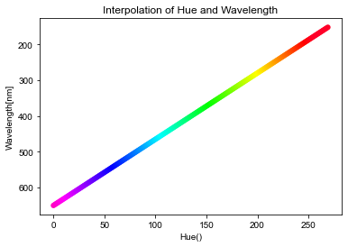

```python
#Array with hue values from 0 degrees to 270 degrees
h_array = np.arange(0,270,1)
h_array.shape

# define vectorized sigmoid
hue2wl_v = np.vectorize(hue2wl)
test = hue2wl_v(h_array)
test.shape
np.min(test)

plt.title("Interpolation of Hue and Wavelength")
plt.xlabel("Hue()")
plt.ylabel("Wavelength[nm]")
plt.scatter(h_array, test, c = cm.gist_rainbow_r(np.abs(h_array)), edgecolor='none')
plt.gca().invert_yaxis()
plt.style.use('seaborn-darkgrid')
plt.show()
```

```python
#Convert hue to wavelength
hues_df['nm'] = hues_df.apply(lambda row : hue2wl(row['hues']), axis = 1)
hues_df['nm'].min()
```

```python
img = cv2.imread('colors.jpg')
#Convert a hue value to wavelength via interpolation
#Assume that visible spectrum is contained between 400-650nm
def hue2wl(h, wlMax = 650, wlMin = 400, hMax = 270, hMin = 0):
    #h *= 2
    hMax /= 2
    hMin /= 2
    wlRange = wlMax - wlMin
    hRange = hMax - hMin
    wl =  wlMax - ((h* (wlRange))/(hRange))
    return wl

def wl2freq(wl):
    wavelength = wl
    sol = 299792458.00 #this is the speed of light in m/s
    sol *= 1e9 #Convert speed of light to nm/s
    freq = (sol / wavelength) * (1e-12)
    return freq

def img2music(img, fName):

    #Get height and width of image
    height, width, _ = img.shape

    #Convet from BGR to HSV
    hsv = cv2.cvtColor(img, cv2.COLOR_BGR2HSV)

    #Populate hues array with H channel for each pixel
    i=0 ; j=0
    hues = []
    for i in range(height):
        for j in range(width):
            hue = hsv[i][j][0] #This is the hue value at pixel coordinate (i,j)
            hues.append(hue)

    #Make pandas dataframe
    hues_df = pd.DataFrame(hues, columns=['hues'])
    hues_df['nm'] = hues_df.apply(lambda row : hue2wl(row['hues']), axis = 1)
    hues_df['freq'] = hues_df.apply(lambda row : wl2freq(row['nm']), axis = 1)
    hues_df['notes'] = hues_df.apply(lambda row : librosa.hz_to_note(row['freq']), axis = 1)
    hues_df['midi_number'] = hues_df.apply(lambda row : librosa.note_to_midi(row['notes']), axis = 1)

    #Convert midi number column to a numpy array
    midi_number = hues_df['midi_number'].to_numpy()

    #Enter MIDI parameters
    degrees  = list(midi_number) # MIDI note number
    track    = 0
    channel  = 0
    time     = 0   # In beats
    duration = 1   # In beats
    tempo    = 240  # In BPM
    volume   = 100 # 0-127, as per the MIDI standard

    #Make MIDI file
    #MyMIDI = MIDIFile(1) # One track (tempo track automatically created)
    #MyMIDI.addTempo(track, time, tempo)
    #for pitch in degrees:
    #    MyMIDI.addNote(track, channel, pitch, time, duration, volume)
    #    time = time + 1
    #with open(fName + ".mid", "wb") as output_file:
    #   MyMIDI.writeFile(output_file)

    #midiName = fName + ".mid"
    print("Done making song from image!")

    return hues_df
```

```python
df = img2music(img,'color')
df
```

```
Done making song from image!
```

```python
#Convert midi number column to a numpy array
sr = 22050 # sample rate
song = df['freq'].to_numpy()
ipd.Audio(song, rate = sr) # load a NumPy array
```

[interactive chart not shown]

```python
a_HarmonicMinor = [220.00, 246.94 ,261.63, 293.66, 329.63, 349.23, 415.30, 440.00]
frequencies = df['freq'].to_numpy()
song = np.array([])
harmony = np.array([])
octaves = np.array([1/4,1,2,1,2])
sr = 22050 # sample rate
T = 0.25    # 0.1 second duration
t = np.linspace(0, T, int(T*sr), endpoint=False) # time variable
#Make a song with numpy array :]
nPixels = int(len(frequencies)/height)
nPixels = 30
#for j in tqdm(range(nPixels), desc="Processing Frame"):#Add progress bar for frames processed
for i in range(nPixels):
    octave = random.choice(octaves)
    val =  octave * frequencies[i]
    note  = 0.5*np.sin(2*np.pi*val*t)
    song  = np.concatenate([song, note])
ipd.Audio(song, rate=sr) # load a NumPy array
```

[interactive chart not shown]